# Python

- 自学 Python 第二天
- 主要学习 *NumPy*, *Matplotlib*, *SciPy*, *Sympy*, *Pandas* 等包

```python
import numpy as np
```

```python
import timeit
def funl (x, y):
     return x**2 + y**3

t_start  =  timeit.default_timer()
z =  funl(109.2, 367.1)
t_end  =   timeit.default_timer()

cost  =  t_end -t_start
print ( 'Time cost of funl is  %f' %cost)
```

```
Time cost of funl is  0.000085
```

## numpy

- NumPy提供了一种新的数据类型：ndarray ($n$ 维数组).
- 与元组和列表不同，数组只能存储相同类型的对象.
- 这使得数组上的操作比列表快得多; 此外, 阵列占用的内存少于列表.
- 数组为列表索引机制提供强大的扩展.

```python
np.array([2, 3, 6, 7])
```

```
array([2, 3, 6, 7])
```

range(start, stop, step) 的所有三个参数即起始值，结束值，步长都是可以用的 另外还有一个数据的 dtype 参数

```python
np.arange(10,100,20,dtype = float)
```

```
array([10., 30., 50., 70., 90.])
```

linspace（start，stop，num）返回数字间隔均匀的样本，按区间[start，stop]计算

```python
np.linspace(0.,2.5,5)
```

```
array([0.   , 0.625, 1.25 , 1.875, 2.5  ])
```

多维数组矩阵

```python
a = np.array([[1, 2, 3],[4, 5, 6]])
a
```

```
array([[1, 2, 3],
       [4, 5, 6]])
```

```python
a.shape
```

```
(2, 3)
```

```python
a.ndim
```

```
2
```

```python
a.size
```

```
6
```

```python
a = np .arange(0, 20, 1)
```

```python
b = a.reshape((4, 5))
b
```

```
array([[ 0,  1,  2,  3,  4],
       [ 5,  6,  7,  8,  9],
       [10, 11, 12, 13, 14],
       [15, 16, 17, 18, 19]])
```

```python
c = a.reshape((20, 1))
c
```

```
array([[ 0],
       [ 1],
       [ 2],
       [ 3],
       [ 4],
       [ 5],
       [ 6],
       [ 7],
       [ 8],
       [ 9],
       [10],
       [11],
       [12],
       [13],
       [14],
       [15],
       [16],
       [17],
       [18],
       [19]])
```

```python
d = a.reshape((-1, 4))
d
```

```
array([[ 0,  1,  2,  3],
       [ 4,  5,  6,  7],
       [ 8,  9, 10, 11],
       [12, 13, 14, 15],
       [16, 17, 18, 19]])
```

```python
a.shape =(4, 5)
a
```

```
array([[ 0,  1,  2,  3,  4],
       [ 5,  6,  7,  8,  9],
       [10, 11, 12, 13, 14],
       [15, 16, 17, 18, 19]])
```

```python
a = np.array([1,2,3,4,5])
b = a.copy ()
```

```python
a
```

```
array([1, 2, 3, 4, 5])
```

```python
b
```

```
array([1, 2, 3, 4, 5])
```

## dot()返回的是两个数组的点积(dot product)

- 如果处理的是一维数组，则得到的是两数组的內积
- 如果是二维数组（矩阵）之间的运算，则得到的是矩阵积

```python
c1 =  np.dot(np.transpose(a), b)
print(c1)
```

```
55
```

```python
c2  = np.dot(a, np.transpose(b))
c2
```

```
55
```

```python
a.dot(b)
```

```
55
```

```python
ax  =  np.reshape(a, (5,1))
bx  =  np.reshape(b, (1,5))
c = np.dot(ax, bx)
c
```

```
array([[ 1,  2,  3,  4,  5],
       [ 2,  4,  6,  8, 10],
       [ 3,  6,  9, 12, 15],
       [ 4,  8, 12, 16, 20],
       [ 5, 10, 15, 20, 25]])
```

## 生成一些特别的矩阵

```python
np.zeros(3)
```

```
array([0., 0., 0.])
```

```python
np.zeros((2, 2), complex)
```

```
array([[0.+0.j, 0.+0.j],
       [0.+0.j, 0.+0.j]])
```

```python
np.ones((2, 3))
```

```
array([[1., 1., 1.],
       [1., 1., 1.]])
```

## 生成随机矩阵

- rand: 0和1之间均匀分布的随机数
- randn: 均值为0，标准差为1的标准（高斯）正态分布

```python
 np.random.rand(2, 4)
```

```
array([[0.53750642, 0.63742898, 0.79165285, 0.02249497],
       [0.81445157, 0.92907138, 0.0087886 , 0.75913063]])
```

```python
np.random.randn(2, 4)
```

```
array([[-0.36617484, -1.28284018,  0.60237681,  0.65587959],
       [ 1.87907335,  0.37542153, -0.47814663, -0.43456756]])
```

## 数组切片

- 以格式start：stop可以用来提取数组的片段（从开始到不包括stop）

```python
a = np.array([0, 1, 2, 3, 4])
a
```

```
array([0, 1, 2, 3, 4])
```

```python
a[1:3]
```

```
array([1, 2])
```

```python
a[:3]
```

```
array([0, 1, 2])
```

```python
a[1:]
```

```
array([1, 2, 3, 4])
```

```python
a[1:-1]
```

```
array([1, 2, 3])
```

- 要获取，例如每个其他元素，您可以在第二个冒号后面指定第三个数字（步骤(step)）：

```python
a [: : 2]
```

```
array([0, 2, 4])
```

```python
a[1:4:2]
```

```
array([1, 3])
```

```python
a = np.arange(12); a.shape =  (3,  4)
a
```

```
array([[ 0,  1,  2,  3],
       [ 4,  5,  6,  7],
       [ 8,  9, 10, 11]])
```

```python
a[1,2]
```

```
6
```

```python
a[:,1]
```

```
array([1, 5, 9])
```

```python
a[2,:]
```

```
array([ 8,  9, 10, 11])
```

## 矩阵元素乘法

- 运算符 * 表示元素乘法，而不是矩阵乘法
- 使用dot（）函数进行矩阵乘法

```python
A = np.array([[1, 2],[3, 4]])
A*A
```

```
array([[ 1,  4],
       [ 9, 16]])
```

```python
np.dot(A, A)
```

```
array([[ 7, 10],
       [15, 22]])
```

## Numpy包含许多常用的数学函数，例如

- np.log
- np.maximum
- np.sin
- np.exp
- np.abs

# scipy库

## SciPy的结构

- scipy.integrate - >积分和普通微分方程
- scipy.linalg - >线性代数
- scipy.ndimage - >图像处理
- scipy.optimize - >优化和根查找(root finding)
- scipy.special - >特殊功能
- scipy.stats - >统计功能
- 线性方程的解 (Solution of linear equations:)

```python
import numpy as np
from scipy import linalg

A = np.random.randn(5, 5)
b = np.random.randn(5)
x = linalg.solve(A, b)     # A x = b#print(x)
x
```

```
array([-1.30084414, -2.07452916, -1.29385325, -2.04200905, -3.24107374])
```

```python
b
```

```
array([ 0.55755531, -0.64602988, -0.56142371,  0.94660639,  1.17992491])
```

```python
np.dot(A,x)
```

```
array([ 0.55755531, -0.64602988, -0.56142371,  0.94660639,  1.17992491])
```

```python
linalg.eig(A)     # eigens#print(eigen)
```

```
(array([-0.44303609+0.j        ,  0.31842257+1.25085714j,
         0.31842257-1.25085714j,  1.37362689+0.j        ,
         2.42421194+0.j        ]),
 array([[-0.22764532+0.j        , -0.00236831-0.27911467j,
         -0.00236831+0.27911467j,  0.54030322+0.j        ,
         -0.41535291+0.j        ],
        [-0.25414425+0.j        , -0.18950614+0.42321927j,
         -0.18950614-0.42321927j,  0.00689487+0.j        ,
         -0.48703586+0.j        ],
        [-0.43498407+0.j        ,  0.70175551+0.j        ,
          0.70175551-0.j        ,  0.75826611+0.j        ,
          0.11347832+0.j        ],
        [-0.56564927+0.j        ,  0.32039984-0.06099399j,
          0.32039984+0.06099399j,  0.10330938+0.j        ,
         -0.59074773+0.j        ],
        [-0.61189711+0.j        , -0.21299589+0.25071478j,
         -0.21299589-0.25071478j, -0.34983506+0.j        ,
          0.47793077+0.j        ]]))
```

```python
linalg.det(A)     # determinant
```

```
-2.457893105971969
```

## Numerical integration

- integration.quad是一维积分的自适应数值积分的函数

```python
from scipy import integrate

def fun(x):
    return np.log(x)

value, error = integrate.quad(fun,0,1)
print(value)
print(error)
```

```
-1.0000000000000004
1.6653345369377348e-15
```

## Statistics in Scipy

```python
from scipy import stats
```

```python
stats.norm.cdf(0)
```

```
0.5
```

```python
stats.norm.cdf(1.2)
```

```
0.8849303297782918
```

## Optimisation: Data fitting

```python
import numpy as np
from scipy.optimize import curve_fit
import matplotlib.pyplot as plt
```

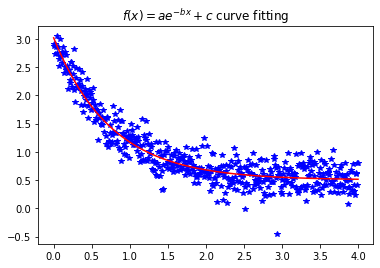

```python
def func(x, a, b, c):
    return a * np.exp(-b * x) + c

x = np.linspace(0, 4, 500)
y = func(x, 2.5, 1.3, 0.5)
ydata = y+0.2*np.random.normal(size=len(x))
popt, pcov = curve_fit(func, x, ydata)#利用curve_fit作简单的拟合，popt为拟合得到的参数,pcov是参数的协方差矩阵
plt.plot(x, ydata, 'b*')
plt.plot(x, func(x, popt[0], \
                    popt[1], popt[2]), 'r-')
plt.title('$f(x)=ae^{-bx}+c$ curve fitting')
```

## Optimisation: Root searching

```python
import numpy as np
from scipy import optimize

def fun(x):
    return np.exp(np.exp(x)) - x**2

# find zero of fun with initial point 0
# by Newton-Raphson
value1 = optimize.newton(fun, 0)
value1
# find zero between (-5,5) by bisection
value2 = optimize.bisect(fun, -5, 5)
```

```python
value1
```

```
-1.1681989617247015
```

```python
value2
```

```
-1.1681989617238742
```

## Matplotlib

- To plot a function, we do

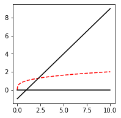

```python
import numpy as np
import matplotlib.pyplot as plt

x = np.linspace(0, 10, 201)
#y = x ** 0.5
#plt.plot(x, y) # default plot
plt.figure(figsize = (3, 3)) # new fig
plt.plot(x, x**0.3, 'r--') # red dashed
plt.plot(x, x-1, 'k-') # continue plot
plt.plot(x, np.zeros_like(x), 'k-')# np.zeros_like(a)指生成一个和你所给数组a相同shape的全0数组
```

## Multiple plotting, legends, labels and title

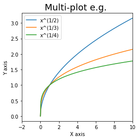

```python
x = np.linspace(0, 10, 201)
plt.figure(figsize = (4, 4))
for n in range(2, 5):
    y = x ** (1 / n)
    plt.plot(x, y, label='x^(1/' \
            + str(n) + ')')
plt.legend(loc = 'best')
plt.xlabel('X axis')
plt.ylabel('Y axis')
plt.xlim(-2, 10)
plt.title('Multi-plot e.g. ', fontsize = 18)
```

### 绘制子图

```
(-10, 40)
```

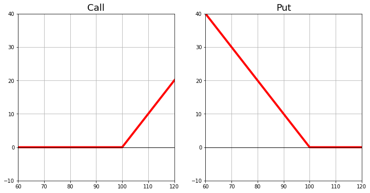

```python
import numpy as np
import matplotlib.pyplot as plt

def pffcall(S, K):
    return np.maximum(S - K, 0.0)
def pffput(S, K):
    return np.maximum(K - S, 0.0)

S = np.linspace(50, 151, 100)
fig = plt.figure(figsize=(12, 6))

sub1 = fig.add_subplot(121)     # col, row, num
sub1.set_title('Call', fontsize = 18)
plt.plot(S, pffcall(S, 100), 'r-', lw = 4)
plt.plot(S, np.zeros_like(S), 'black',lw = 1)
sub1.grid(True)
sub1.set_xlim([60, 120])
sub1.set_ylim([-10, 40])

sub2 = fig.add_subplot(122)
sub2.set_title('Put', fontsize = 18)
plt.plot(S, pffput(S, 100), 'r-', lw = 4)
plt.plot(S, np.zeros_like(S), 'black',lw = 1)
sub2.grid(True)
sub2.set_xlim([60, 120])
sub2.set_ylim([-10, 40])
#Remark：这里，可以把Figure，即fig理解为一张大画布，你把它分成了两个子区域(sub1和sub2)，然后在每个子区域各画了一幅图。
```

### Adding texts to plots

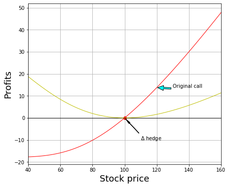

```python
import numpy as np
from scipy.stats import norm
import matplotlib.pyplot as plt

def call(S, K=100, T=0.5, vol=0.6, r=0.05):
    d1 = (np.log(S/K) + (r + 0.5 * vol**2) \
          *T) / np.sqrt(T) / vol
    d2 = (np.log(S/K) + (r - 0.5 * vol**2) \
          *T) / np.sqrt(T) / vol
    return S * norm.cdf(d1) - K * \
    np.exp(-r * T) * norm.cdf(d2)

def delta(S, K=100, T=0.5, vol=0.6, r=0.05):
    d1 = (np.log(S/K) + (r + 0.5 * vol**2)\
          *T) / np.sqrt(T) / vol
    return norm.cdf(d1)

S = np.linspace(40, 161, 100)
fig = plt.figure(figsize=(7, 6))
ax = fig.add_subplot(111)
plt.plot(S,(call(S)-call(100)),'r',lw=1)
plt.plot(100, 0, 'ro', lw=1)
plt.plot(S,np.zeros_like(S), 'black', lw = 1)
plt.plot(S,call(S)-delta(100)*S- \
    (call(100)-delta(100)*100), 'y', lw = 1)

ax.annotate('$\Delta$ hedge', xy=(100, 0), \
            xytext=(110, -10),arrowprops= \
            dict(headwidth =3,width = 0.5, \
            facecolor='black', shrink=0.05))
ax.annotate('Original call', xy= \
            (120,call(120)-call(100)),xytext\
            =(130,call(120)-call(100)),\
            arrowprops=dict(headwidth =10,\
            width = 3, facecolor='cyan', \
            shrink=0.05))
plt.grid(True)
plt.xlim(40, 160)
plt.xlabel('Stock price', fontsize = 18)
plt.ylabel('Profits', fontsize = 18)
```

- 3D plot of a function with 2 variables

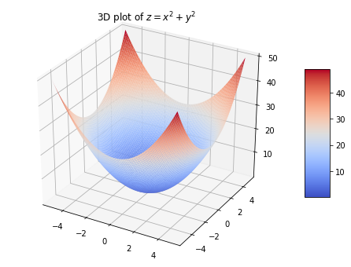

```python
import numpy as np
import matplotlib.pyplot as plt
from matplotlib import cm
from mpl_toolkits.mplot3d import Axes3D

x, y = np.mgrid[-5:5:100j, -5:5:100j]
z = x**2 + y**2
fig = plt.figure(figsize=(8, 6))
ax = plt.axes(projection='3d')
surf = ax.plot_surface(x, y, z, rstride=1,\
                       cmap=cm.coolwarm, cstride=1, \
                       linewidth=0)
fig.colorbar(surf, shrink=0.5, aspect=5)
plt.title('3D plot of $z = x^2 + y^2$')
```